# heidi

[figure not shown]

**Institution Profile**

**Classification:** Professions-focused Undergraduate/Graduate-Doctorate Small

**Size:** Small

**Award Level Focus:** Undergraduate/Graduate-Doctorate

**UG Program Mix:** Professions-focused

**Grad Program Mix:** Professions-focused

**Research Activity:** No research designation

**Student Access & Earnings:** Lower Access, Medium Earnings

**Top Degree Programs — 2023-24**

| Program | % of Degrees |
| --- | --- |
| Rehabilitation and Therapeutic Professions. | 20.6% |
| Sports, Kinesiology, and Physical Education/Fitness. | 14.9% |
| Allied Health Diagnostic, Intervention, and Treatment Professions. | 9.5% |

**Location**

[interactive chart not shown]

#### Higher Education Institutional Data Interface (HEIDI)

HEIDI is a dashboard tool created by the Casagrande Institute to report data for institutions of higher education.

#### Casagrande Institute

The [Casagrande Institute](https://www.viterbo.edu/casagrande-institute/) helps institutions develop effective compensation practices for executives, faculty, and staff.

**Group Overview**

- **AUTO**: Created by IPEDS in 2024-25 based on an internal grouping process involving Level, Control, Carnegie classification, and other variables.
- **CUSTOM**: The group of comparison institutions submitted to IPEDS by Springfield in 2024-25.
- **REVERSE**: The group of institutions that included Springfield in their 2024-25 IPEDS custom group.

**Group Membership**

| Institution | AUTO | CUSTOM | REVERSE |
| --- | --- | --- | --- |
| Alvernia University | ✓ |  |  |
| American International College |  | ✓ |  |
| Andrews University | ✓ |  |  |
| Assumption University |  | ✓ | ✓ |
| Augsburg University |  |  | ✓ |
| Bay Path University |  |  | ✓ |
| Belhaven University | ✓ |  |  |
| Bellarmine University | ✓ |  |  |
| Bethel University | ✓ |  |  |
| Brenau University | ✓ |  |  |

[output cut: 49 more lines]

**AUTO**

[interactive table not shown]

**CUSTOM**

[interactive table not shown]

**REVERSE**

[interactive table not shown]

**AUTO**

**Financial and Student Positioning of Springfield Within the AUTO Group**

| Metric | **AUTO Group** n | **AUTO Group** Min | **AUTO Group** p25 | **AUTO Group** Median | **AUTO Group** p75 | **AUTO Group** Max | **Spread** Spread | **Springfield** Springfield | **Springfield** Percentile | **Springfield** % of Median |
| --- | --- | --- | --- | --- | --- | --- | --- | --- | --- | --- |
| Revenue | 34 | 42.2M | 74.8M | 84.6M | 100.1M | 131.9M |  | 97.6M | 72 | 115% |
| Expenses | 34 | 45.6M | 66.7M | 84.2M | 99.5M | 117.9M |  | 101.7M | 81 | 121% |
| Margin | 34 | −15.1M | −3.3M | 3.3M | 7.8M | 27.5M |  | −4.1M | 22 | NA |
| Endowment | 34 | 8.0M | 60.2M | 72.8M | 120.0M | 311.9M |  | 103.3M | 66 | 142% |
| Avg Net Price | 34 | 14.0k | 20.9k | 23.9k | 28.3k | 32.6k |  | 30.0k | 84 | 125% |
| Avg Net Price + 0.04 * Endowment / UG FTE | 34 | 15.1k | 22.1k | 27.1k | 29.8k | 39.0k |  | 32.2k | 87 | 119% |
| 12-Month Unduplicated Headcount | 34 | 2,609 | 3,207 | 3,918 | 4,452 | 5,642 |  | 2,849 | 4 | 73% |
| Undergrad FTE | 34 | 927 | 1,582 | 1,919 | 2,326 | 2,648 |  | 1,926 | 51 | 100% |
| Grad FTE | 34 | 283 | 494 | 724 | 999 | 1,771 |  | 733 | 54 | 101% |
| Doc Prof Prac FTE | 26 | 25 | 135 | 212 | 292 | 691 |  | 161 | 33 | 76% |
| Total FTE | 34 | 2,364 | 2,483 | 2,968 | 3,196 | 3,392 |  | 2,820 | 41 | 95% |
| Student-to-Faculty Ratio | 34 | 9.0 | 11.0 | 12.0 | 14.0 | 20.0 |  | 11.0 | 22 | 92% |
| Undergrad Pell % | 34 | 19 | 25 | 32 | 39 | 49 |  | 22 | 4 | 70% |
| Program Breadth (distinct 4-digit CIPs) | 34 | 23 | 36 | 43 | 50 | 63 |  | 37 | 29 | 86% |
| Top 5 Programs % of Completions | 34 | 41 | 46 | 56 | 61 | 77 |  | 60 | 71 | 107% |
| Distinct Award Levels Offered | 34 | 4 | 5 | 6 | 7 | 10 |  | 5 | 22 | 83% |

Data from IPEDS for the 2024-25 academic year. Group values exclude data from Springfield.  
% of Median is suppressed where the group median is negative or where signs differ, as the ratio is not meaningful.

**CUSTOM**

**Financial and Student Positioning of Springfield Within the CUSTOM Group**

| Metric | **CUSTOM Group** n | **CUSTOM Group** Min | **CUSTOM Group** p25 | **CUSTOM Group** Median | **CUSTOM Group** p75 | **CUSTOM Group** Max | **Spread** Spread | **Springfield** Springfield | **Springfield** Percentile | **Springfield** % of Median |
| --- | --- | --- | --- | --- | --- | --- | --- | --- | --- | --- |
| Revenue | 13 | 51.8M | 115.2M | 166.0M | 276.7M | 469.0M |  | 97.6M | 27 | 59% |
| Expenses | 13 | 50.4M | 109.3M | 159.0M | 209.5M | 348.8M |  | 101.7M | 27 | 64% |
| Margin | 13 | −2.3M | 6.3M | 21.1M | 36.5M | 120.1M |  | −4.1M | 4 | NA |
| Endowment | 13 | 28.3M | 86.9M | 230.9M | 330.8M | 764.5M |  | 103.3M | 35 | 45% |
| Avg Net Price | 13 | 19.7k | 29.7k | 35.3k | 40.0k | 48.6k |  | 30.0k | 42 | 85% |
| Avg Net Price + 0.04 * Endowment / UG FTE | 13 | 23.0k | 32.3k | 38.9k | 43.8k | 51.9k |  | 32.2k | 27 | 83% |
| 12-Month Unduplicated Headcount | 13 | 2,211 | 2,919 | 5,035 | 6,849 | 12,695 |  | 2,849 | 27 | 57% |
| Undergrad FTE | 13 | 1,192 | 2,488 | 3,482 | 4,373 | 7,293 |  | 1,926 | 27 | 55% |
| Grad FTE | 13 | 58 | 371 | 547 | 1,450 | 3,492 |  | 733 | 73 | 134% |
| Doc Prof Prac FTE | 6 | 199 | 248 | 454 | 934 | 1,286 |  | 161 | 8 | 35% |
| Total FTE | 13 | 1,980 | 2,546 | 4,073 | 5,990 | 11,147 |  | 2,820 | 35 | 69% |
| Student-to-Faculty Ratio | 13 | 10.0 | 11.0 | 12.0 | 13.0 | 16.0 |  | 11.0 | 35 | 92% |
| Undergrad Pell % | 13 | 12 | 16 | 17 | 24 | 45 |  | 22 | 69 | 129% |
| Program Breadth (distinct 4-digit CIPs) | 13 | 32 | 40 | 47 | 59 | 68 |  | 37 | 12 | 79% |
| Top 5 Programs % of Completions | 13 | 31 | 41 | 45 | 46 | 53 |  | 60 | 100 | 133% |
| Distinct Award Levels Offered | 13 | 3 | 4 | 6 | 7 | 10 |  | 5 | 42 | 83% |

Data from IPEDS for the 2024-25 academic year. Group values exclude data from Springfield.  
% of Median is suppressed where the group median is negative or where signs differ, as the ratio is not meaningful.

**REVERSE**

**Financial and Student Positioning of Springfield Within the REVERSE Group**

| Metric | **REVERSE Group** n | **REVERSE Group** Min | **REVERSE Group** p25 | **REVERSE Group** Median | **REVERSE Group** p75 | **REVERSE Group** Max | **Spread** Spread | **Springfield** Springfield | **Springfield** Percentile | **Springfield** % of Median |
| --- | --- | --- | --- | --- | --- | --- | --- | --- | --- | --- |
| Revenue | 18 | 2.6M | 53.2M | 76.1M | 109.9M | 276.7M |  | 97.6M | 75 | 128% |
| Expenses | 18 | 2.9M | 53.4M | 77.3M | 100.9M | 290.4M |  | 101.7M | 75 | 132% |
| Margin | 18 | −17.7M | −1.1M | 2.4M | 7.3M | 68.3M |  | −4.1M | 14 | NA |
| Endowment | 17 | 3.9M | 46.7M | 76.3M | 173.2M | 403.2M |  | 103.3M | 62 | 135% |
| Avg Net Price | 17 | 13.3k | 22.4k | 26.5k | 31.1k | 40.0k |  | 30.0k | 74 | 113% |
| Avg Net Price + 0.04 * Endowment / UG FTE | 17 | 13.6k | 24.4k | 27.6k | 34.5k | 43.8k |  | 32.2k | 68 | 117% |
| 12-Month Unduplicated Headcount | 18 | 213 | 2,032 | 3,538 | 4,363 | 11,153 |  | 2,849 | 47 | 81% |
| Undergrad FTE | 18 | 159 | 976 | 1,426 | 2,520 | 4,554 |  | 1,926 | 64 | 135% |
| Grad FTE | 17 | 56 | 244 | 578 | 1,200 | 1,767 |  | 733 | 68 | 127% |
| Doc Prof Prac FTE | 12 | 25 | 92 | 229 | 374 | 1,393 |  | 161 | 38 | 70% |
| Total FTE | 18 | 159 | 1,755 | 2,417 | 3,272 | 6,734 |  | 2,820 | 69 | 117% |
| Student-to-Faculty Ratio | 18 | 8.0 | 9.0 | 11.0 | 13.0 | 15.0 |  | 11.0 | 58 | 100% |
| Undergrad Pell % | 18 | 12 | 24 | 32 | 44 | 64 |  | 22 | 19 | 68% |
| Program Breadth (distinct 4-digit CIPs) | 18 | 5 | 32 | 39 | 48 | 59 |  | 37 | 42 | 95% |
| Top 5 Programs % of Completions | 18 | 42 | 45 | 50 | 60 | 100 |  | 60 | 75 | 120% |
| Distinct Award Levels Offered | 18 | 1 | 4 | 6 | 7 | 9 |  | 5 | 47 | 91% |

Data from IPEDS for the 2024-25 academic year. Group values exclude data from Springfield.  
% of Median is suppressed where the group median is negative or where signs differ, as the ratio is not meaningful.

**AUTO**

**Revenue**

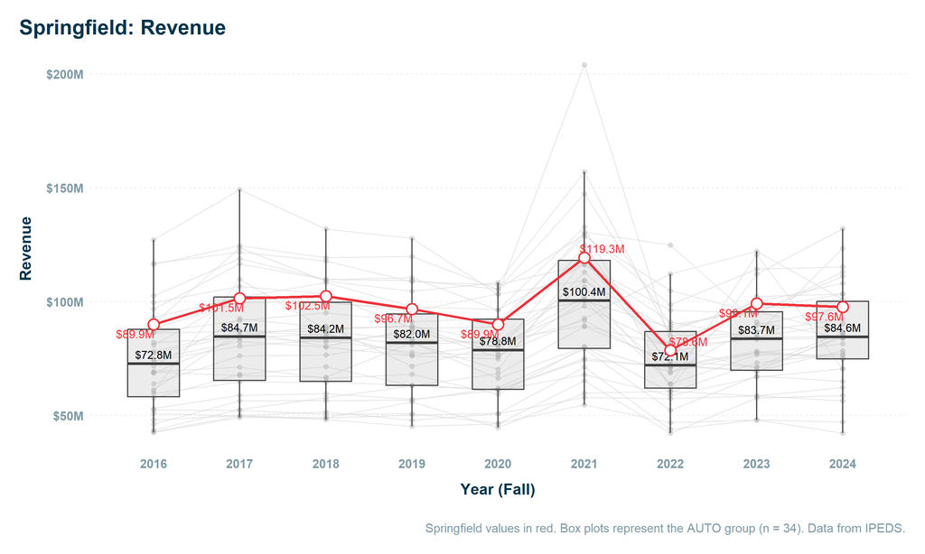

**Expenses**

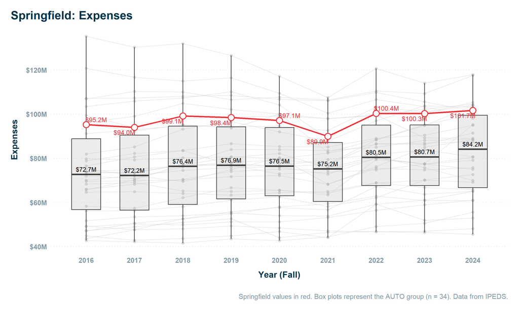

**Margin**

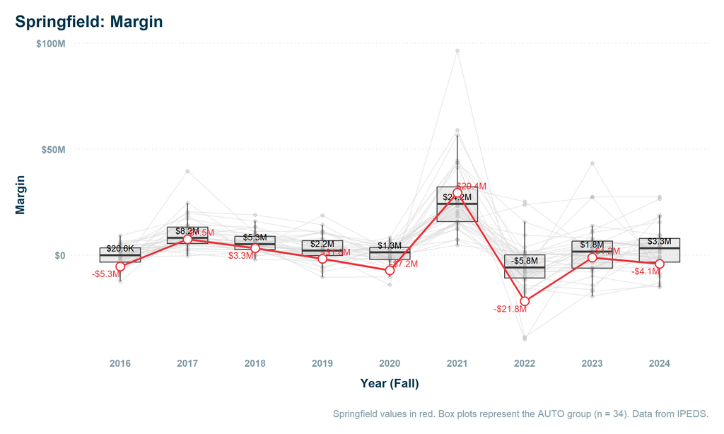

**Endowment**

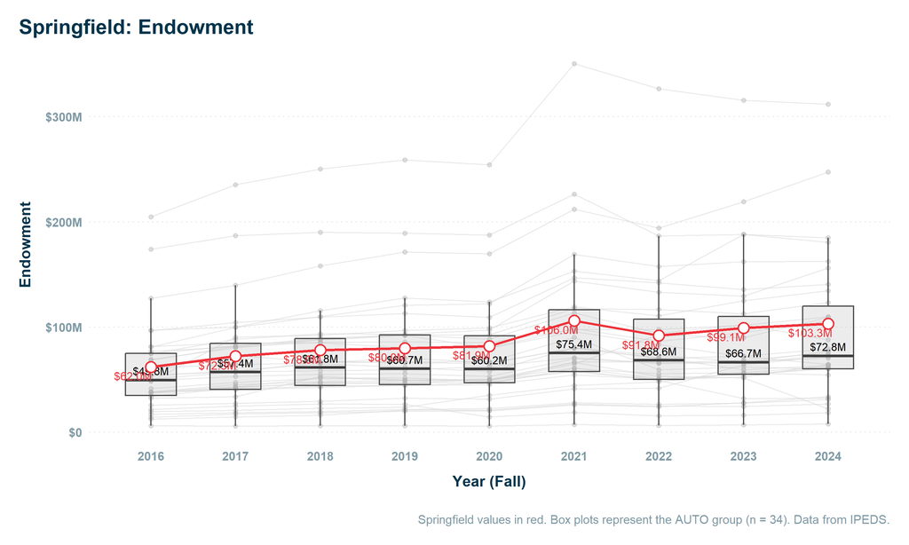

**Avg Net Price**

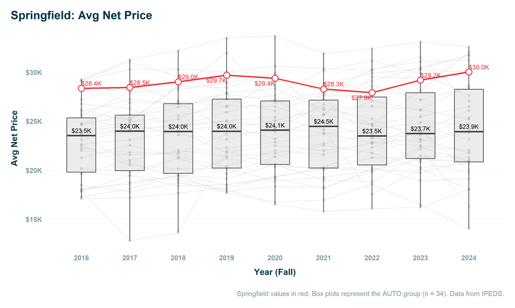

**Avg Net Price + 0.04 * Endowment / UG FTE**

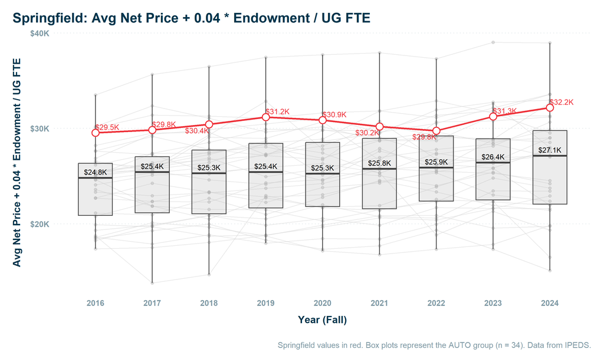

**12-Month Unduplicated Headcount**

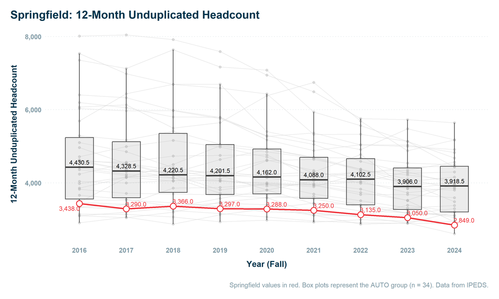

**Undergrad FTE**

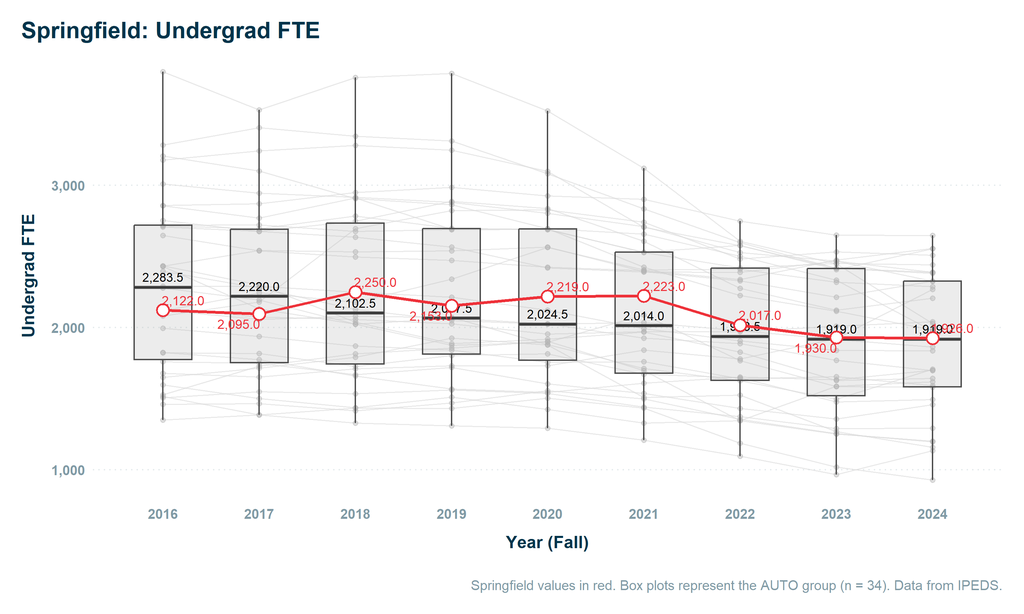

**Grad FTE**

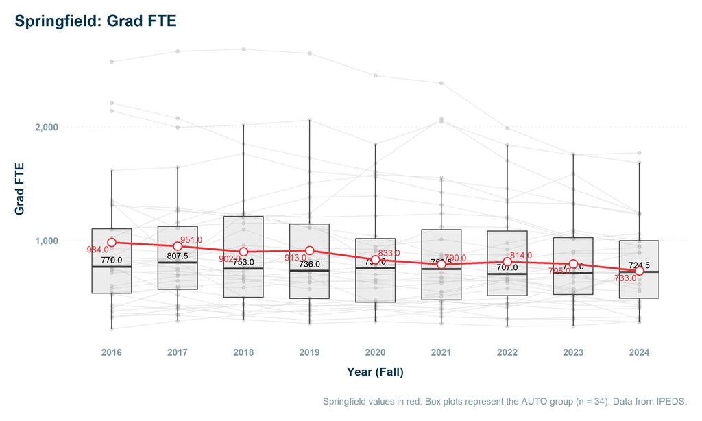

**Doc Prof Prac FTE**

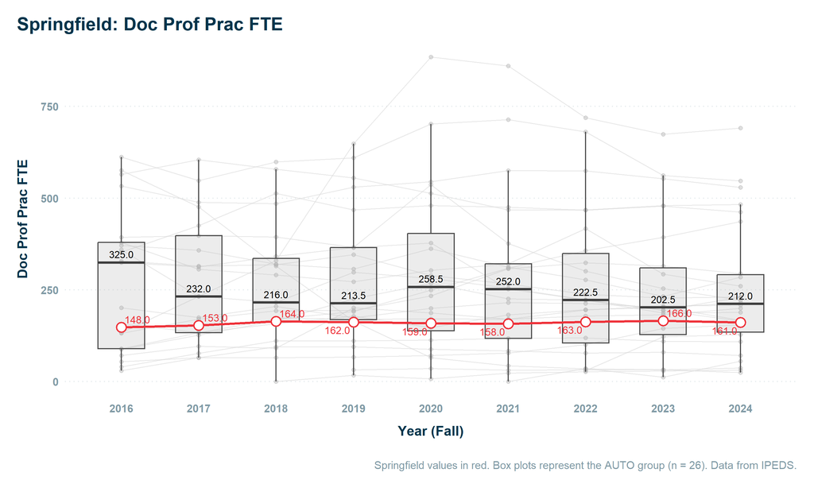

**Total FTE**

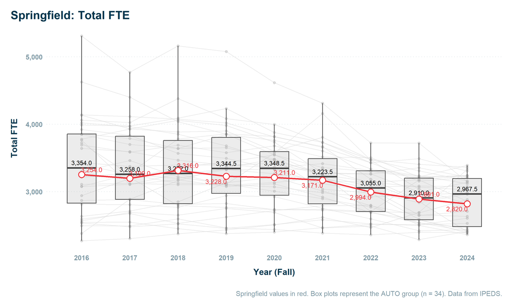

**Student-to-Faculty Ratio**

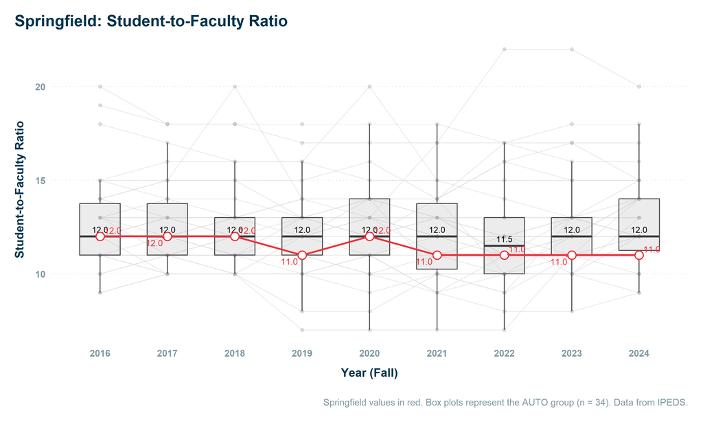

**Undergrad Pell %**

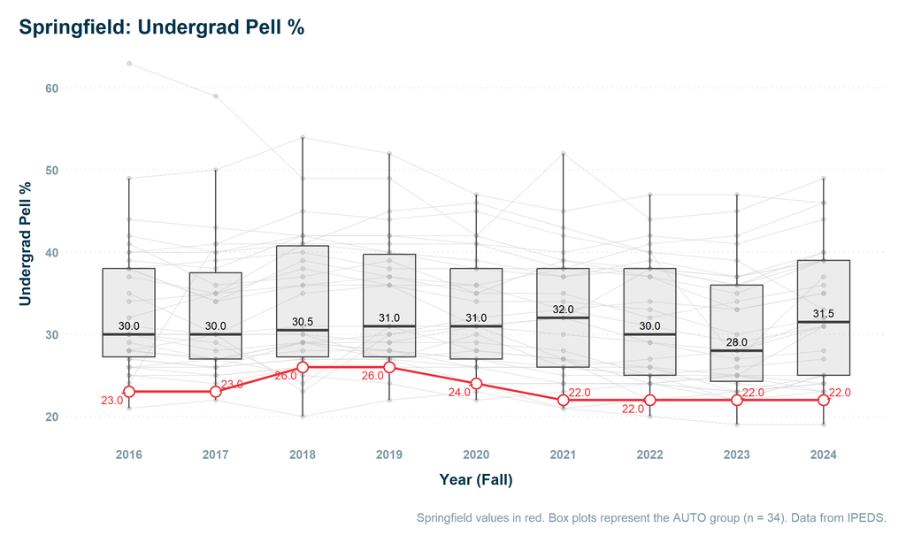

**Program Breadth (distinct 4-digit CIPs)**

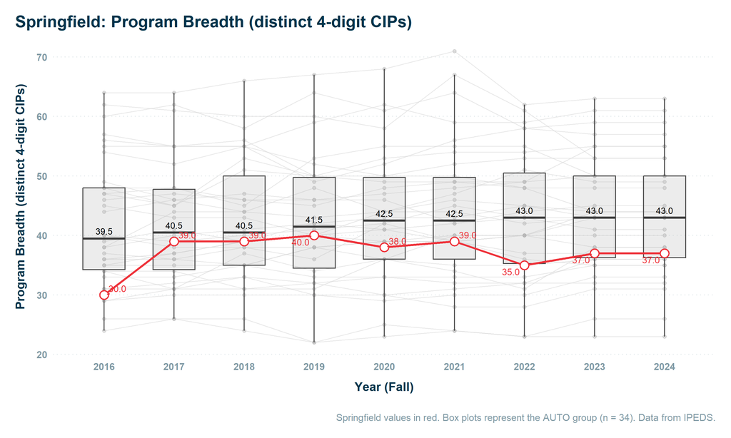

**Top 5 Programs % of Completions**

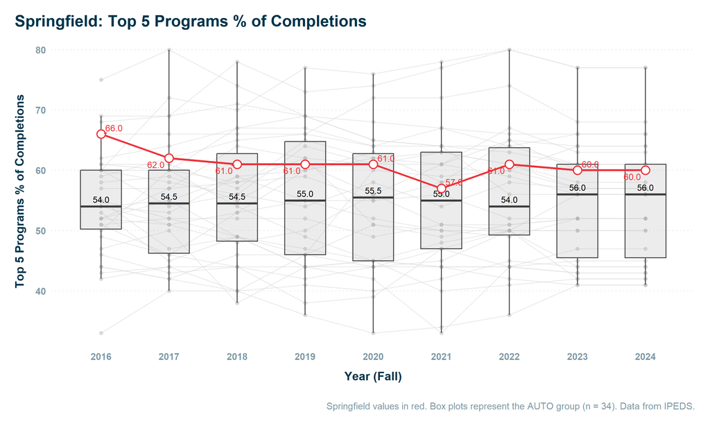

**Distinct Award Levels Offered**

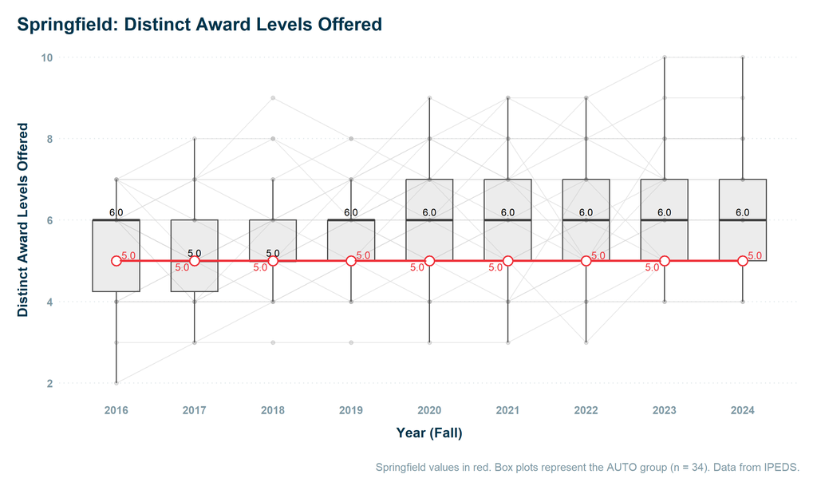

**CUSTOM**

**Revenue**

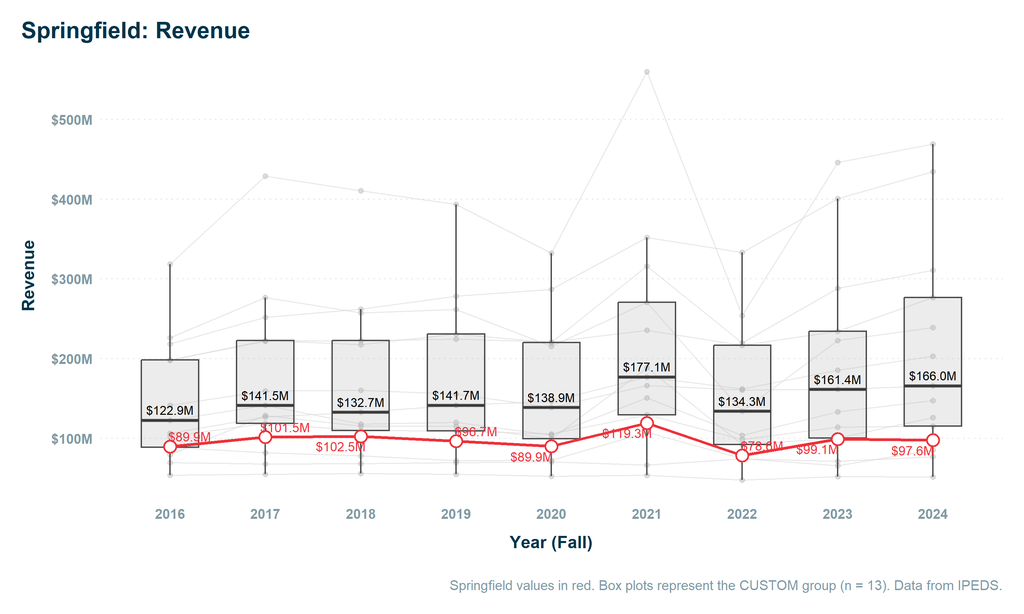

**Expenses**

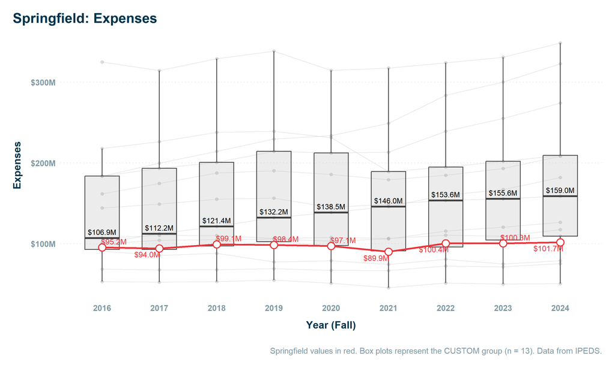

**Margin**

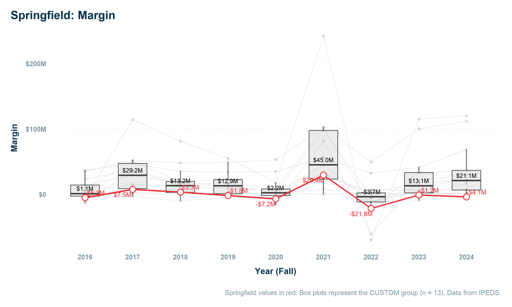

**Endowment**

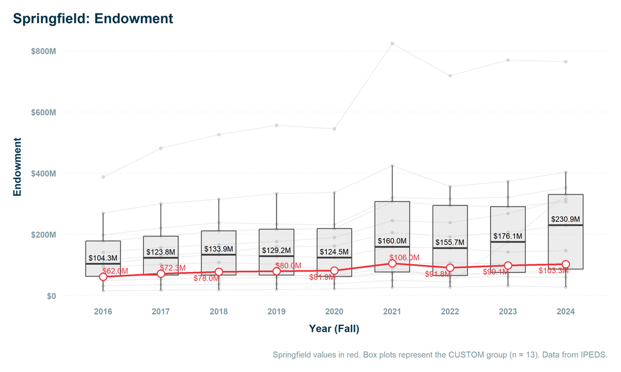

**Avg Net Price**

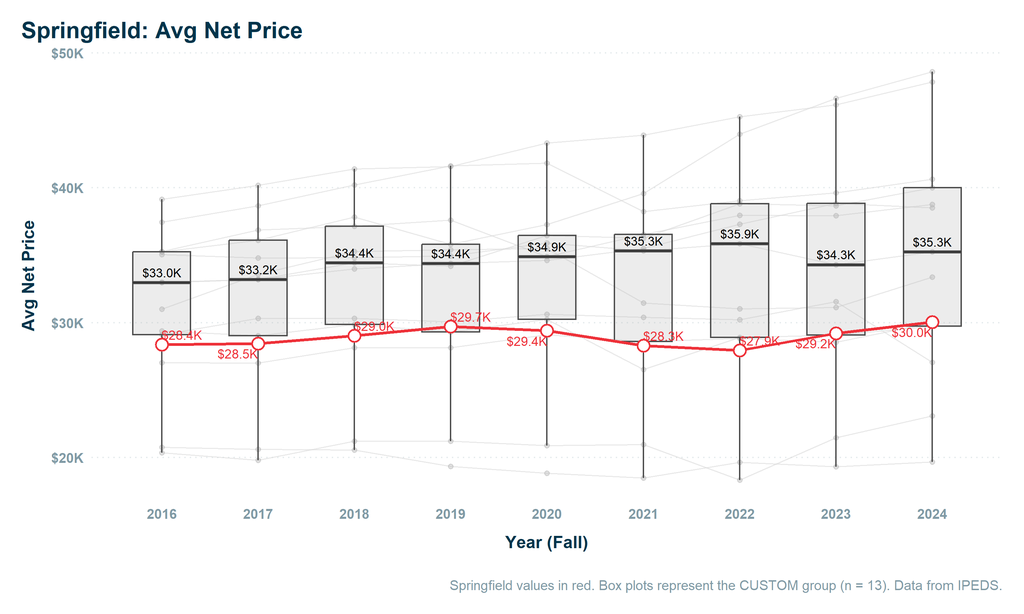

**Avg Net Price + 0.04 * Endowment / UG FTE**

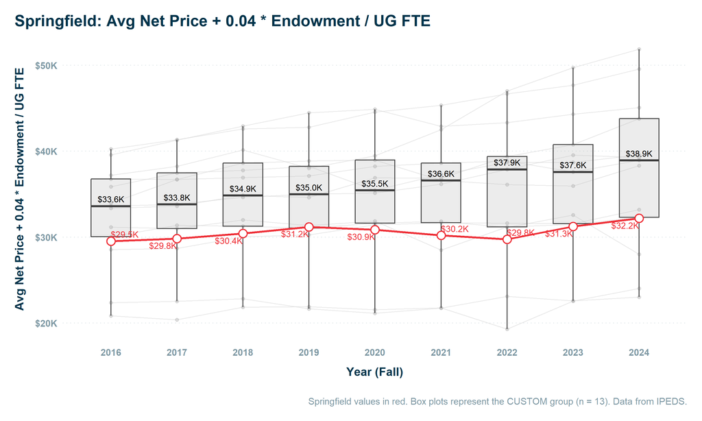

**12-Month Unduplicated Headcount**

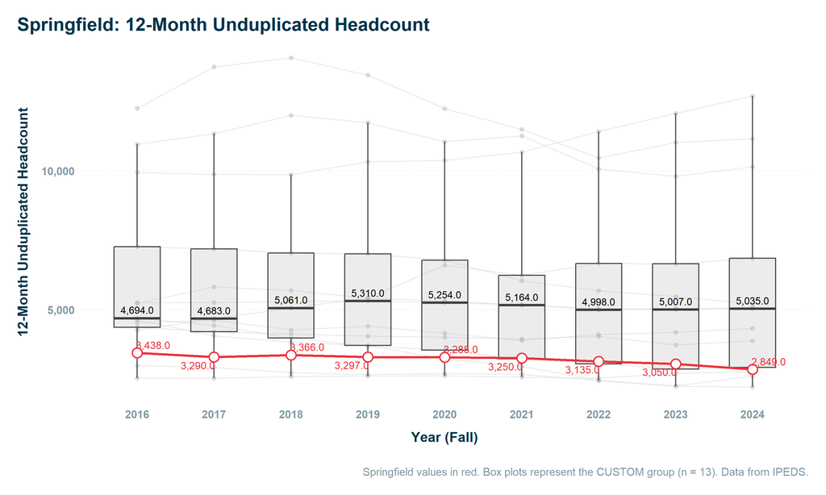

**Undergrad FTE**

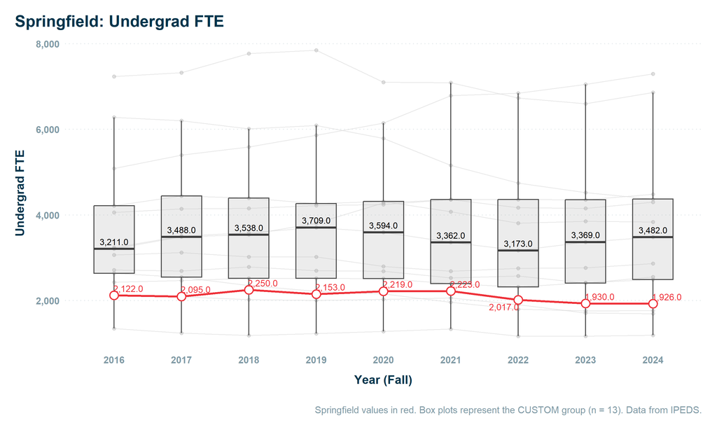

**Grad FTE**

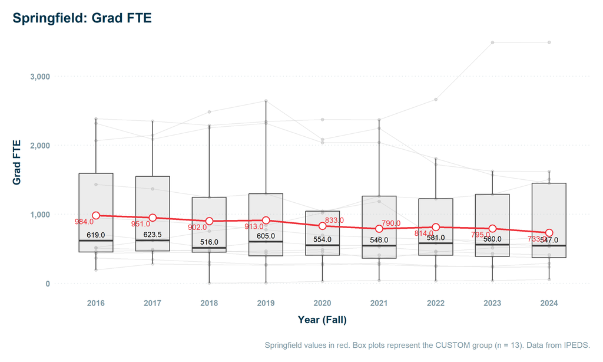

**Doc Prof Prac FTE**

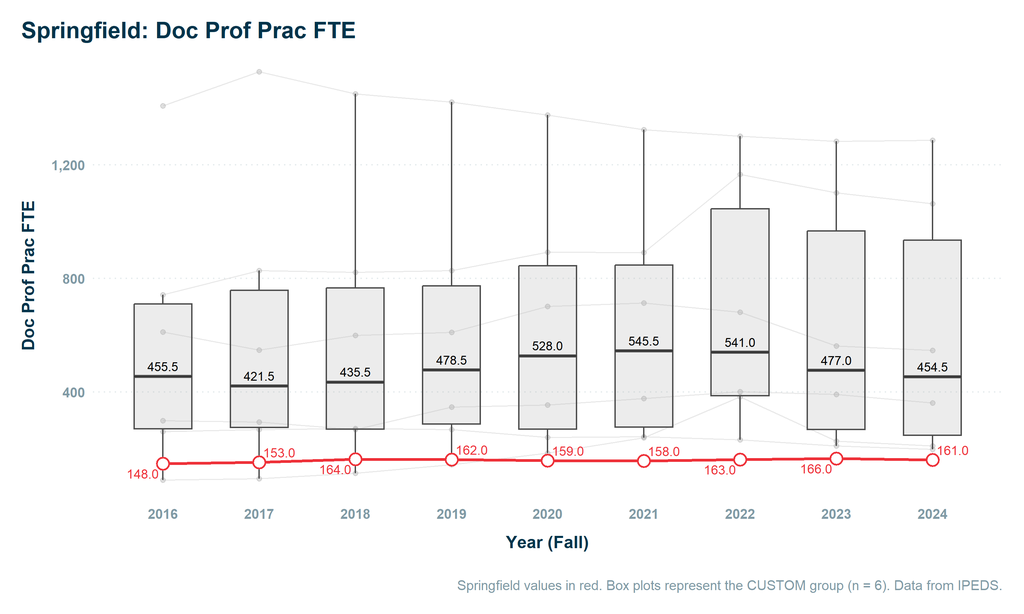

**Total FTE**

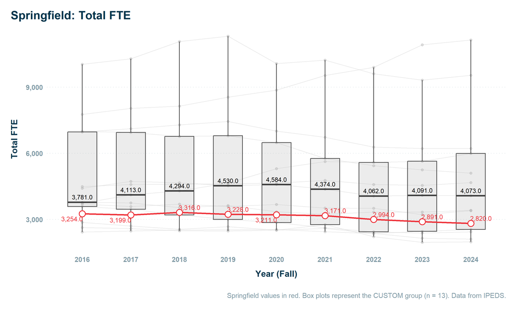

**Student-to-Faculty Ratio**

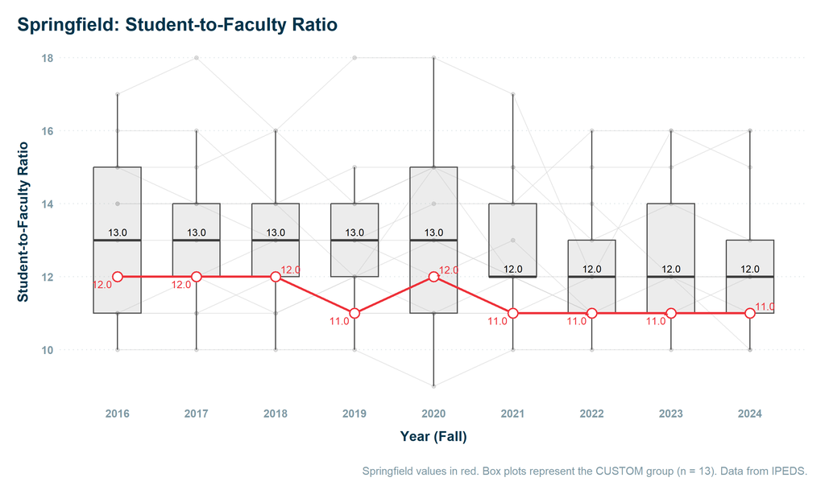

**Undergrad Pell %**

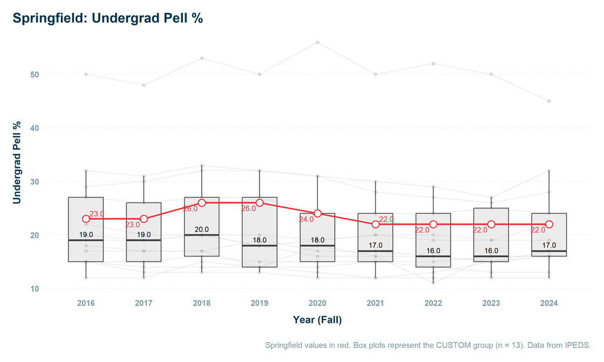

**Program Breadth (distinct 4-digit CIPs)**

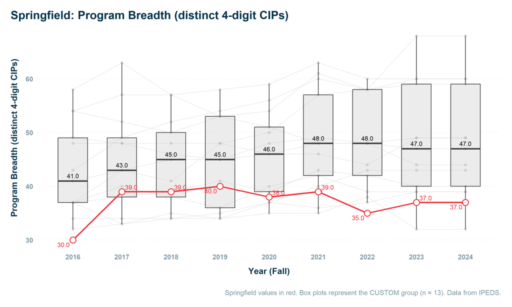

**Top 5 Programs % of Completions**

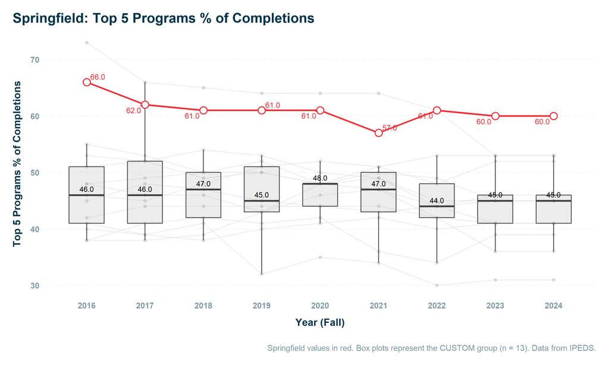